### Question 1: Data inspection

First, I load all required packages and libraries.

```r
##load libraries

if (!("limma" %in% rownames(installed.packages()))){
  source("http://bioconductor.org/biocLite.R")
  biocLite("limma")
}

if (!("edgeR" %in% rownames(installed.packages()))){
  source("http://bioconductor.org/biocLite.R")
  biocLite("edgeR")
}

library(limma)
library(edgeR)
library(ggplot2)
library(lattice)
suppressPackageStartupMessages(library(dplyr))
```

#### 1.1 Download and inspect the data (1 point)

Here, I load the data and the metadata from the files provided.

```r
##load data and design
design <- read.table("data/NHBE_design.txt", header=T)
data <- read.table("data/NHBE_transcriptome_data.txt", header=T)
```

I just inspect the dataframes here to see what my data looks like.

```r
# What does our data look like?
str(design)
```

```
## 'data.frame':    23 obs. of  3 variables:
##  $ ExternalID: Factor w/ 23 levels "GSM270872","GSM270873",..: 11 3 2 1 9 8 7 14 13 16 ...
##  $ Treatment : Factor w/ 2 levels "cigarette_smoke",..: 2 2 2 2 2 2 2 1 1 1 ...
##  $ time      : Factor w/ 4 levels "1_h","2_h","24_h",..: 3 1 1 1 4 4 4 1 1 2 ...
```

```r
head(data)
```

```
##         GSE10718_Biomat_1 GSE10718_Biomat_10 GSE10718_Biomat_11
## 1294_at          7.900022           7.623666           8.224398
## 1316_at          6.126008           5.846865           6.299318
## 1320_at          6.822491           7.616309           7.217153
## 1431_at          6.633596           5.698143           6.221293
## 1438_at          6.948795           7.509875           7.291645
## 1487_at          9.887123           9.957308           9.987827
##         GSE10718_Biomat_12 GSE10718_Biomat_13 GSE10718_Biomat_14
## 1294_at           8.009710           7.607968           7.448574
## 1316_at           5.910947           6.623939           6.824437
## 1320_at           6.172960           7.201396           7.397821
## 1431_at           6.055411           6.885087           7.023587
## 1438_at           7.950410           7.867940           7.554235
## 1487_at           9.655931           9.815862           9.925754
##         GSE10718_Biomat_15 GSE10718_Biomat_16 GSE10718_Biomat_17
## 1294_at           7.414247           7.671862           7.892385
## 1316_at           6.884227           6.830394           6.453085
## 1320_at           6.782186           6.987745           5.845809
## 1431_at           6.591812           6.454693           6.176024
## 1438_at           7.270903           7.563386           7.237671
## 1487_at          10.011030          10.020255           9.885514
##         GSE10718_Biomat_19 GSE10718_Biomat_2 GSE10718_Biomat_20
## 1294_at           7.804841          7.721433           7.548707
## 1316_at           6.658476          6.569794           5.806634
## 1320_at           6.831755          6.674275           6.282316
## 1431_at           6.192702          6.741030           5.568127
## 1438_at           6.959041          7.045873           8.039412
## 1487_at           9.805115          9.885153           9.862000
##         GSE10718_Biomat_21 GSE10718_Biomat_22 GSE10718_Biomat_23
## 1294_at           6.343507           7.797584           7.951058
## 1316_at           7.064967           6.485319           7.084865
## 1320_at           7.234590           6.750336           7.111929
## 1431_at           5.768635           5.585600           7.135406
## 1438_at           7.623666           7.317369           7.826105
## 1487_at           9.780051           9.638231           9.731842
##         GSE10718_Biomat_24 GSE10718_Biomat_3 GSE10718_Biomat_4
## 1294_at           7.877641          7.510909          7.309565
## 1316_at           6.237747          6.384493          6.885804
## 1320_at           6.972026          6.979904          7.621911
## 1431_at           6.343507          6.727300          6.481674
## 1438_at           7.032091          7.056781          8.457894
## 1487_at           9.850717         10.157299          9.902884
##         GSE10718_Biomat_5 GSE10718_Biomat_6 GSE10718_Biomat_7
## 1294_at          8.004972          7.502813          7.500043
## 1316_at          7.100588          6.421699          6.269029
## 1320_at          7.294042          7.684150          7.116839
## 1431_at          5.722269          6.281308          6.625745
## 1438_at          7.729401          7.541195          8.171871
## 1487_at          9.697970          9.636326         10.035322
##         GSE10718_Biomat_8 GSE10718_Biomat_9
## 1294_at          7.509491          7.735819
## 1316_at          6.534320          6.888977
## 1320_at          6.613354          6.708225
## 1431_at          6.523722          7.063494
## 1438_at          7.674406          7.417900
## 1487_at          9.938759         10.106026
```

Number of genes in our data is 22737.

```r
dim(data)[1]
```

```
## [1] 22737
```

Number of samples in our data is 23.

```r
dim(data)[2]
```

```
## [1] 23
```

Check for treatment and time by viewing a table summary of the variables.

```r
with(design,table(Treatment,time))
```

```
##                  time
## Treatment         1_h 2_h 24_h 4_h
##   cigarette_smoke   2   3    3   3
##   control           3   3    3   3
```

#### 1.2 Basic data manipulation (1 point)

Note that the current variable time in this dataset is a factor (time column of design.txt). Create a new variable which is a numeric version of time (basically a new column in the metadata’s dataframe). It should represent a numeric count of hours. You will need this new quantitative variable later in the analysis.

So here, I just display my time factor so that I can accurately construct the numeric vector. I then add another factor in my design data frame and specify my time vector as the values.

```r
design$time
```

```
##  [1] 24_h 1_h  1_h  1_h  4_h  4_h  4_h  1_h  1_h  2_h  24_h 2_h  2_h  4_h
## [15] 4_h  4_h  24_h 24_h 24_h 24_h 2_h  2_h  2_h
## Levels: 1_h 2_h 24_h 4_h
```

```r
time <- c(24,1,1,1,4,4,4,1,1,2,24,2,2,4,4,4,24,24,24,24,2,2,2)
design$numeric.time=time
```

#### 1.3 Basic graphing (1 point)

Create a plot showing the gene expression data for a random probe and the averages for all possible combinations of agent and time.

Hint: Choose a random probe first. Use position, panels or facets, and color to convey the treatment, time of the samples. Report the average expression of the selected probe for all possible combinations of treatment and time. Treat time like a factor in this question.

```r
# randomly pick a gene
set.seed(987)
(randomProbe <- sample(1:nrow(data), 1))
```

```
## [1] 10852
```

```r
# This is the probe we selected
rownames(data)[randomProbe]
```

```
## [1] "220347_at"
```

Now, I construct my data.frame for plotting by extracting the random probe from my data matrix, and plugging it into my design matrix.

```r
# pull it from our data matrix and stick it in our design frame
toPlot <- data.frame(design, Expression = as.vector(unlist(t(data[randomProbe, ]))))
str(toPlot)
```

```
## 'data.frame':    23 obs. of  5 variables:
##  $ ExternalID  : Factor w/ 23 levels "GSM270872","GSM270873",..: 11 3 2 1 9 8 7 14 13 16 ...
##  $ Treatment   : Factor w/ 2 levels "cigarette_smoke",..: 2 2 2 2 2 2 2 1 1 1 ...
##  $ time        : Factor w/ 4 levels "1_h","2_h","24_h",..: 3 1 1 1 4 4 4 1 1 2 ...
##  $ numeric.time: num  24 1 1 1 4 4 4 1 1 2 ...
##  $ Expression  : num  3.41 6.31 6.63 6.46 4.54 ...
```

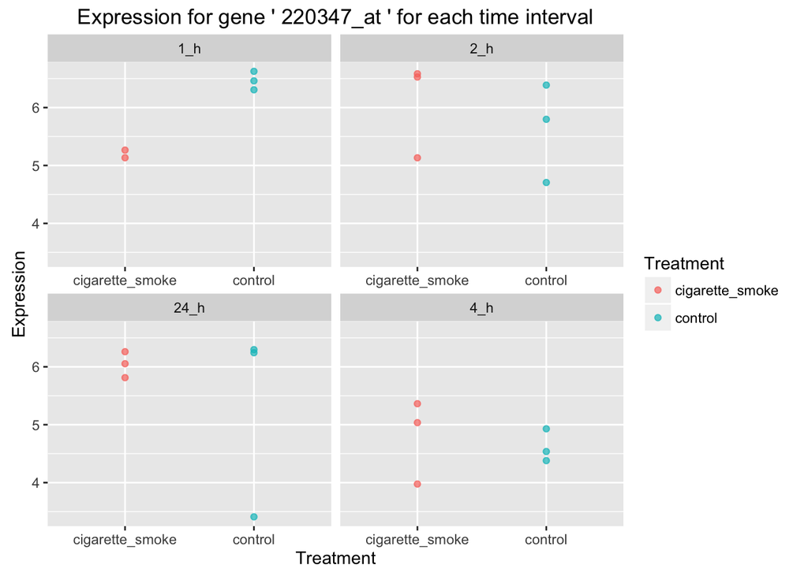

```r
# create a stripplot
ggplot(toPlot, aes(x = Treatment, y = Expression, color = Treatment)) + facet_wrap(~ time, scales="free_x") + geom_point(alpha = 0.7) + ggtitle(paste("Expression for gene '", rownames(data)[randomProbe],"' for each time interval"))
```

The question specifies averaging, however I wasn’t too certain on what the resulting plot should present, so I interpretted the question as follows: For each time step, take the average expression of the samples for each treatment group. My resulting plot consists of one facet where colour depicts time, x-axis depicts treatment group, and y-axis depicts the average expression.

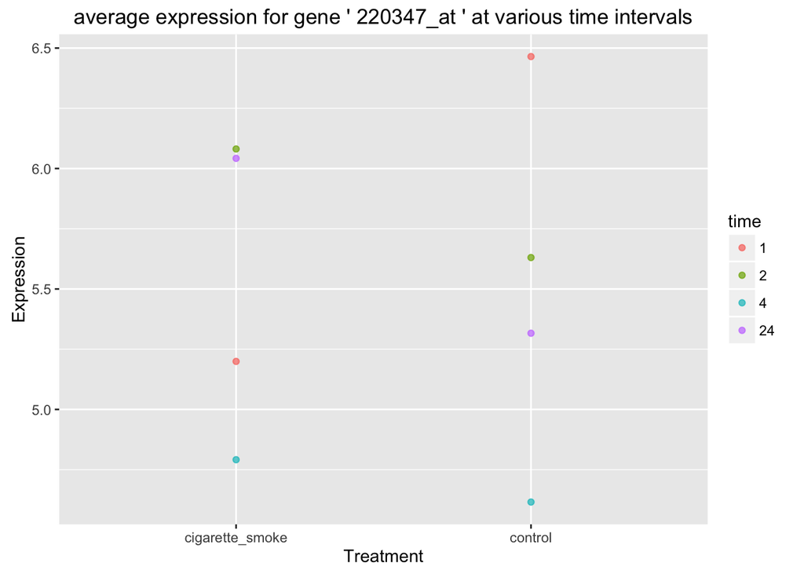

```r
# aggregate to take a look
mean.exp <-aggregate(Expression ~ Treatment + numeric.time, toPlot, FUN = mean)

time = as.factor(mean.exp$numeric.time)
ggplot(mean.exp, aes(x = Treatment, y = Expression, color = time)) + geom_point(alpha = 0.7) + ggtitle(paste("average expression for gene '", rownames(data)[randomProbe],"' at various time intervals"))
```

### Question 2: Assessing data quality

After loading the data, the second must-do thing is to sanity check the data.

#### 2.1 Examine the sample-to-sample correlations in a heatmap (2 points)

- Create the following sample-sample correlation matrices.
  - Order the samples by `time`; within each time group, sort on the other factor, i.e., `agent` (treatment).

First I specify my colour palettes for plotting :nail_care:

```r
################## PALETTES FOR PLOTTING :) ###############################################
library(gplots)
library(RColorBrewer)
#display.brewer.all()

PuRd <- colorRampPalette(brewer.pal(n = 9, "Blues"))
palette1 <- c('#ffffcc','#ffeda0','#fed976','#feb24c','#fd8d3c','#fc4e2a','#e31a1c','#bd0026','#800026')
palette2 <- c('#c7e9b4','#7fcdbb','#41b6c4','#1d91c0','#225ea8','#253494','#081d58')

orange <- c('#fdd0a2','#fdae6b','#fd8d3c','#f16913','#d94801','#a63603','#7f2704')
blues <- c('#9ecae1','#6baed6','#4292c6','#2171b5','#08519c','#08306b')
greens <- c('#d9f0a3','#addd8e','#78c679','#41ab5d','#238443','#006837','#004529')
###########################################################################################
```

I sort explicitely before taking the correlation and feeding my data to heatmap.2, instead of implicitely in the heatmap graphing function.

```r
#pipeline a sort on time then treatment
timeTreat<-design %>% add_rownames() %>% arrange(numeric.time,Treatment)

#transpose our matrix so we can extract genes as columns
matDat <- as.matrix(t(data))
str(matDat)
```

```
##  num [1:23, 1:22737] 7.9 7.62 8.22 8.01 7.61 ...
##  - attr(*, "dimnames")=List of 2
##   ..$ : chr [1:23] "GSE10718_Biomat_1" "GSE10718_Biomat_10" "GSE10718_Biomat_11" "GSE10718_Biomat_12" ...
##   ..$ : chr [1:22737] "1294_at" "1316_at" "1320_at" "1431_at" ...
```

```r
# Take the correlation and plot heat map
timeTreat.ordered <- matDat[timeTreat$rowname,]
str(timeTreat.ordered)
```

```
##  num [1:23, 1:22737] 7.67 7.89 7.62 8.22 8.01 ...
##  - attr(*, "dimnames")=List of 2
##   ..$ : chr [1:23] "GSE10718_Biomat_16" "GSE10718_Biomat_17" "GSE10718_Biomat_10" "GSE10718_Biomat_11" ...
##   ..$ : chr [1:22737] "1294_at" "1316_at" "1320_at" "1431_at" ...
```

```r
corr.timeTreat <- cor(t(timeTreat.ordered))
diag(corr.timeTreat) <- NA

## specify category labels for ore informative display of data
treatmentGroup <- palette2[as.numeric(timeTreat$Treatment)]
timeGroup <- palette1[as.numeric(timeTreat$time)]

par(cex.main=1)
map.one<- heatmap.2(corr.timeTreat,Rowv = NA, Colv = NA, scale="none",dendrogram ="none", trace="none",col=PuRd(256), cexCol=0.5,cexRow=0.5, RowSideColors = timeGroup, ColSideColors = treatmentGroup,  srtRow =-45, srtCol = 45, main = "correlation of genes ordered by time then treatment")
```

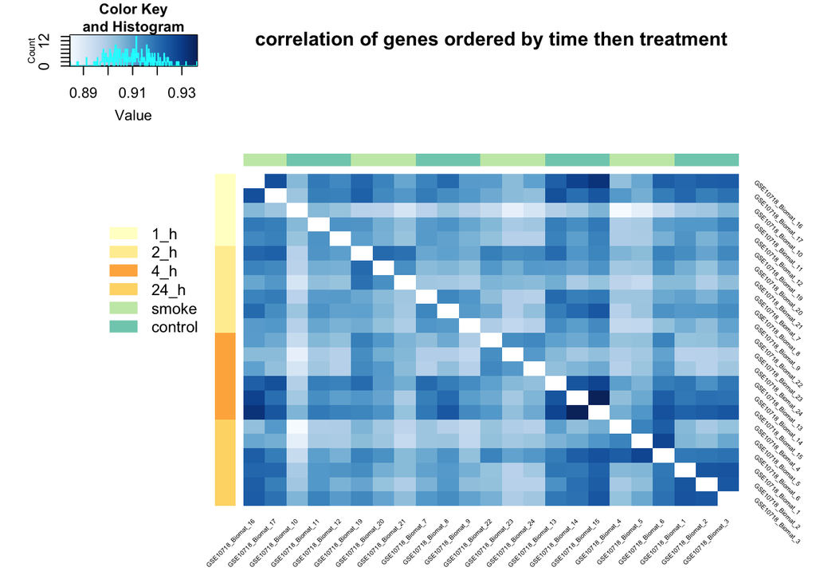

```
- Order the samples by `agent`; and within each agent group, sort by `time`.
```

```r
# Make a legend to show categories
par(lend = 1)
legend("left",      # location of the legend on the heatmap plot
    legend = c(as.character(unique(timeTreat$time)), c("smoke", "control")),
    col = c(unique(timeGroup),unique(treatmentGroup)),
    lty= 1,
    lwd = 10,
    cex=0.8,
    bty = "n"
)
```

```r
# Take the second correlation and plot heat map
#pipeline a sort treatment then time
treatTime<-design %>% arrange(Treatment,numeric.time)

treatTime.ordered <- matDat[treatTime$ExternalID,]
str(treatTime.ordered)
```

```
##  num [1:23, 1:22737] 7.8 6.34 7.88 7.95 7.51 ...
##  - attr(*, "dimnames")=List of 2
##   ..$ : chr [1:23] "GSE10718_Biomat_22" "GSE10718_Biomat_21" "GSE10718_Biomat_24" "GSE10718_Biomat_23" ...
##   ..$ : chr [1:22737] "1294_at" "1316_at" "1320_at" "1431_at" ...
```

```r
corr.treatTime <- cor(t(treatTime.ordered))
diag(corr.treatTime) <- NA

treatmentGroup <- orange[as.numeric(treatTime$Treatment)]
timeGroup <- greens[treatTime$numeric.time]
timeGroup[which(is.na(timeGroup))] <- '#006837'

par(cex.main=1)
map.two<- heatmap.2(corr.treatTime, main = "correlation of genes ordered by treatment then time", Rowv = NA, Colv = NA, scale="none",dendrogram ="none", trace="none",col=PuRd(256), cexCol=0.4,cexRow=0.4, RowSideColors = treatmentGroup, ColSideColors = timeGroup,srtRow =-45, srtCol = 45)
```

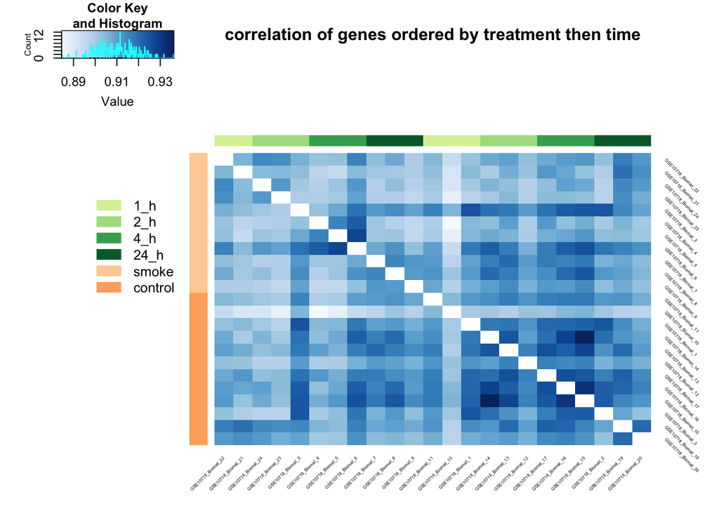

```r
# Make a legend to show categories
par(lend = 1)
legend("left",      # location of the legend on the heatmap plot
    legend = c(as.character(unique(treatTime$time)), c("smoke", "control")),
    col = c(unique(timeGroup),unique(treatmentGroup)),
    lty= 1,
    lwd = 10,
    cex=0.8,
    bty = "n"
)
```

- Interpret your results. What does the sample correlation matrix tell us about the overall impact of time and agent?

The heatmaps show clear correlations

#### 2.2 Assess the presence of outlier samples (1 point)

- Comment on the potential presence of outliers (if any) based on the sample correlation matrices created in Q2a.

- Try to go beyond merely “eyeballing”, and make a quantitative statement about presence of an outlier: e.g., quantify for each sample, whether it “sticks out” compared to the other samples.

```r
outlier <- data$"GSE10718_Biomat_10"
outlier.metadata <- design["GSE10718_Biomat_10",]
```

- If any sample does “stick out” from the previous step, examine it in the context of its experimental group (e.g., given a sample that is least similar to all other samples: does it correlate with samples treated with same agent better than other samples treated with a different agent?)

## By extracting the outlier and taking a closer look at the respective metadata, we can see that the Sample was a control, at hour 1. It seems to stick out in both contexts (time AND treatment)

### Question 3: Differential expression with respect to treatment

#### 3.1 Linear model (1 point)

- Fit a linear model, modeling expression level of each probe using treatment as a single covariate. (Hint: Lecture 10 on limma)

In order to specify treatment as a covariate, I design my model matrix around that single factor. I build a contrast matrix to investigate the interaction effects of smoke and control ###### This is one method

```r
# extract treatment covariate
myModel <- model.matrix(~ 0 + Treatment, design)
str(myModel)
```

```
##  num [1:23, 1:2] 0 0 0 0 0 0 0 1 1 1 ...
##  - attr(*, "dimnames")=List of 2
##   ..$ : chr [1:23] "GSE10718_Biomat_1" "GSE10718_Biomat_10" "GSE10718_Biomat_11" "GSE10718_Biomat_12" ...
##   ..$ : chr [1:2] "Treatmentcigarette_smoke" "Treatmentcontrol"
##  - attr(*, "assign")= int [1:2] 1 1
##  - attr(*, "contrasts")=List of 1
##   ..$ Treatment: chr "contr.treatment"
```

```r
# let's rename the columns for readibility
colnames(myModel) <- c("smoke", "control")
myFit <- lmFit(data, myModel)
ebayesFit <- eBayes(myFit)

# contrasts
contrast.matrix <- makeContrasts(smoke-control, levels=myModel)
myOtherFit <- contrasts.fit(myFit, contrast.matrix)
ebFitTheSecond <- eBayes(myOtherFit)
hits <- topTable(ebFitTheSecond, coef=1, adjust = "fdr", number = 'inf')
```

- Write out in English and as an equation the model you are using to assess differential expression. In the context of that model, what statistical test are you performing?

Our regression model takes the form: y = Xα + ε, where X is our model matrix. The first column specifies Treatment. The first column is “Smoke” group and the second column is “Control” group. The rows specify gene So, a single gene response yi = α1xi1 + α2xi2 + ε, will be a weighted (by alpha) combination of treatment as a covariate (by xi).

Using limma we are fitting a linear model to all genes in our data, and making use of emperical bayes to compute moderated t-statistics(gene-wise test of null by the specified contrast of interest, in our case: smoke-control) and accounting for gene-specific variances.

#### 3.2 Look at the hits (1 point)

- How many hits (probes) are associated with treatment at unadjusted p-value 1e-3?

My linear model identifies 805 hits

```r
# Show in a table how many hits have unadjusted p-vale <1e-3
table(hits$P.Value < 1e-3)
```

```
##
## FALSE  TRUE
## 21932   805
```

How may are associated with treatment at FDR 0.05?

The FDR is the adjusted p value. My model identifies 1238 hits at FDR 0.05.

```r
table(hits$adj.P.Val < 0.05)
```

```
##
## FALSE  TRUE
## 21499  1238
```

- Take the top 50 probes as your “hits” and create a heatmap of their expression levels and sort the hits by p-values and the samples by treatment.

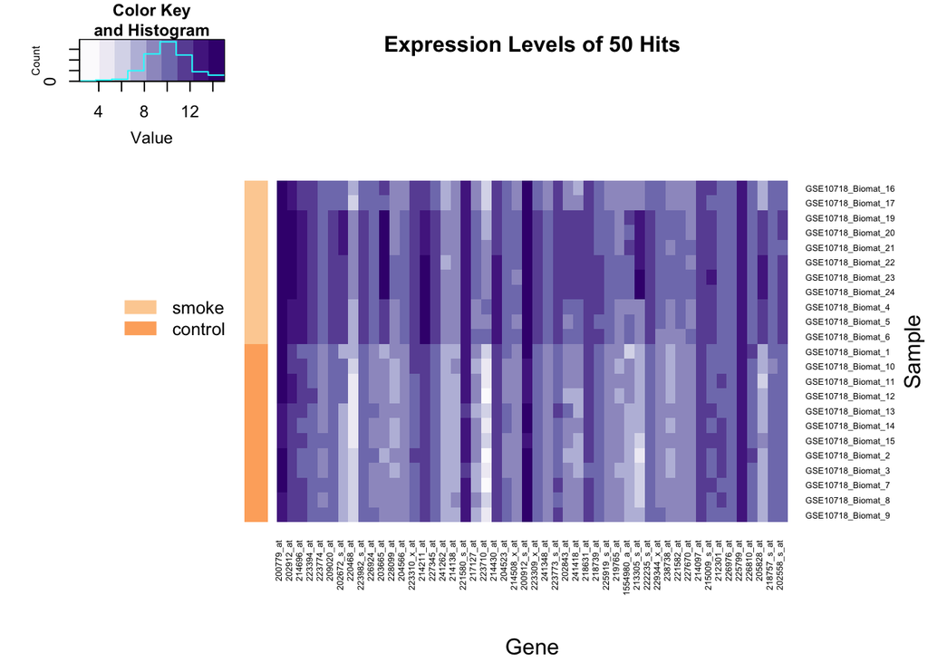

```r
myProbes <- rownames(hits[1:50,])
expInterest <- data[myProbes,]
hits <- hits[order(hits$P.Value), , drop = FALSE]
ordered.samples <- data[rownames(hits[1:50,]),order(design$Treatment)]

treatment.ornge<- orange[(design[order(design$Treatment),])$Treatment]

par(cex.main=1)
map.hits<- heatmap.2(t(as.matrix(ordered.samples)), xlab = "Gene", ylab="Sample", main = "Expression Levels of 50 Hits",Rowv = NA, Colv = NA, scale="none",dendrogram ="none", trace="none",col=c('#fcfbfd','#efedf5','#dadaeb','#bcbddc','#9e9ac8','#807dba','#6a51a3','#54278f','#3f007d'), cexCol=0.6,cexRow=0.6, margins = c(8, 8), RowSideColors=treatment.ornge)
# Make a legend to show categories
par(lend = 1)
legend("left",      # location of the legend on the heatmap plot
    legend = c("smoke", "control"),
    col = unique(treatment.ornge),
    lty= 1,
    lwd = 10,
    cex=0.8,
    bty = "n"
)
```

Sanity check, what are the dimensions of our subset?

```r
dim(ordered.samples)
```

```
## [1] 50 23
```

50 probes and 23 patients. Sounds about right!

- What is the (estimated) false discovery rate of this “hits” list? How many of these hits do we expect to be false discoveries?

FDR specifies that rate at which we expect to encounter falsely identified hits (genes that look interesting under our null, but are not actually significant)

Our hits are already ordered by increasing adjusted p value. I interpret this questions to imply our estimated FDR would be denoted by the largest adjusted p-value in our hit list. That would be hit#50’s FDR, which is aproximately 0.001. This implies that .1% of significant tests will result in false positives. That is, .1% of our observed 50 “hits”, which is 0.05 of a gene, which is the same as saying that we expect no false positives in our top 50 probes.

```r
hits[50,]$adj.P.Val
```

```
## [1] 0.001035992
```

```r
table(hits[1:50,]$adj.P.Val < 0.0011)
```

```
##
## TRUE
##   50
```

### Question 4: Differential expression with respect to time

For this question, time is treated as a quantitative covariate (unit: hours).

#### 4.1 Linear model (1 point)

- You know the drill! Fit a linear model for assessing the effect of time on gene expression

This time, I specify time as a single covariate. My contrast matrix then compares all possible combinations of time. So, interaction of each time point with each other.

```r
# extract treatment covariate
myTimeModel <- model.matrix(~ 0 + time, design)
str(myTimeModel)
```

```
##  num [1:23, 1:4] 0 1 1 1 0 0 0 1 1 0 ...
##  - attr(*, "dimnames")=List of 2
##   ..$ : chr [1:23] "GSE10718_Biomat_1" "GSE10718_Biomat_10" "GSE10718_Biomat_11" "GSE10718_Biomat_12" ...
##   ..$ : chr [1:4] "time1_h" "time2_h" "time24_h" "time4_h"
##  - attr(*, "assign")= int [1:4] 1 1 1 1
##  - attr(*, "contrasts")=List of 1
##   ..$ time: chr "contr.treatment"
```

```r
# let's rename the columns for readibility
colnames(myTimeModel) <- c("hour1", "hour2", "hour24", "hour4")
myTimeFit <- lmFit(data, myTimeModel)
ebayesTimeFit <- eBayes(myTimeFit)

# contrasts
contrast.matrix.time <- makeContrasts(hour1-hour2, hour1-hour24, hour1-hour4, hour2-hour24, hour2-hour4, hour24-hour4, levels=myTimeModel)

myTimeFit2 <- contrasts.fit(myTimeFit, contrast.matrix.time)
ebayesTimeFit2 <- eBayes(myTimeFit2)
timeHits <- topTable(ebayesTimeFit2, number = 'inf')
```

- How many hits are associated with time at unadjusted p-value 1e-3? At FDR 0.05?

Using my model, I find 671 hits at unadjusted p-value 1e-3, and 934 at FDR 0.05.

```r
table(timeHits$P.Value < 1e-3)
```

```
##
## FALSE  TRUE
## 22066   671
```

```r
table(timeHits$adj.P.Val < 0.05)
```

```
##
## FALSE  TRUE
## 21803   934
```

> For questions 6 - 8, you will work with data originally published in [A comprehensive comparison of RNA-Seq-based transcriptome analysis from reads to differential gene expression and cross-comparison with microarrays: a case study in *Saccharomyces cerevisiae*.](http://dx.doi.org/10.1093%2Fnar%2Fgks804). The authors used two different platforms – microarrays and RNA-Seq – to obtain gene expression data for yeast grown in two conditions: batch medium and chemostat. They then compared the results of differential expression analysis (DEA) across platforms. We will work with their data obtained from the NCBI SRA and GEO repositories. Because of some differences in pre-processing your results will differ from theirs.

### Question 6: Microarray analysis

The six samples in this study, 3 replicates for each of the two conditions, were analysed on the Affymetrix Yeast Genome Array 2.0 platform. We have already downloaded the raw CEL files from GEO and normalised them. The normalized data is saved in the file GSE37599-data.tsv

#### 6.1 Data loading and QC (2 points)

The labels on two of the samples have been swapped, that is one of the batch samples has been labelled as chemostat and vice-versa.

- First, load the normalized data. What are dimensions of the dataset? In addition to reporting number of rows and columns, make it clear what rows and columns represent and how you’re interpreting column names.

The dimensions are 10928 rows by 6 columns. Rows are genes, and columns are samples. (3 samples per group)

```r
##load data and design
Q6data <- read.table("data/GSE37599-data.tsv", header=T, row.names = 1)
dim(Q6data)
```

```
## [1] 10928     6
```

```r
str(Q6data)
```

```
## 'data.frame':    10928 obs. of  6 variables:
##  $ b1: num  11.15 2.16 1.49 9.01 6.95 ...
##  $ b2: num  6.8 3.18 1.43 9.46 6.9 ...
##  $ b3: num  6.71 3.13 1.82 9.23 6.96 ...
##  $ c1: num  10.95 2.5 1.46 8.97 6.85 ...
##  $ c2: num  6.7 3.05 2.08 9.28 6.9 ...
##  $ c3: num  11.07 2.44 1.62 9 6.89 ...
```

```r
# Just checking if our data has any NAs
any(is.na(Q6data))
```

```
## [1] FALSE
```

- Produce the plots described below and explain how they allow you to identify the swapped samples.
  - (High volume) scatter plot matrix

```r
library(lattice)
# Here I just check that I subset my data frame correctly. I want to consider samples b1:3 and c1:3 only, I don't want gene names
head(Q6data)
```

```
##                   b1       b2       b3        c1       c2        c3
## 1769308_at 11.145506 6.795593 6.708003 10.945878 6.698862 11.070725
## 1769309_at  2.164329 3.177408 3.128950  2.498308 3.047169  2.444188
## 1769310_at  1.488300 1.427200 1.815698  1.462075 2.079007  1.623036
## 1769311_at  9.006138 9.461821 9.234618  8.972233 9.276710  9.004997
## 1769312_at  6.945715 6.895895 6.955463  6.851454 6.900187  6.892854
## 1769313_at  7.815192 6.600131 6.534413  7.770245 6.564123  7.851777
```

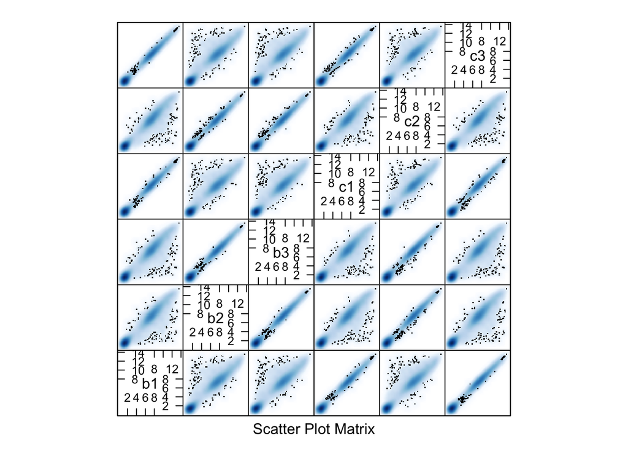

```r
splotmatrix <- splom(Q6data, panel = panel.smoothScatter, raster = TRUE)
print(splotmatrix)
```

- A heatmap of the first 100 genes

This heatmap shows us where there may be inconsistensies in a pattern that groups would be making. This heat map clearly shows a disrupt in the pattern at samples b1 and c2. They look to be out of place in their respective groups, suggesting the sample labels may be swapped.

```r
library(ggplot2)
suppressPackageStartupMessages(library(dplyr))

# convert desired subset of dataframe to matrix for heatmap.2
matDat <- as.matrix(Q6data)

#sanity check, we should have 100 genes and 6 samples.
dim(matDat[1:100,])
```

```
## [1] 100   6
```

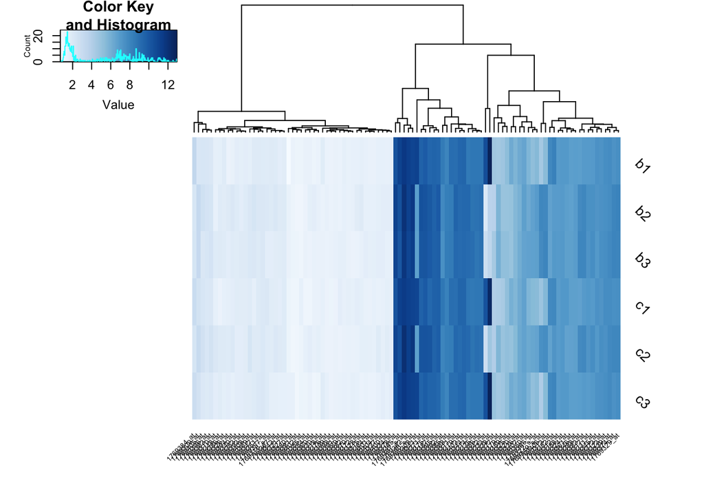

```
- Compute the Pearson correlation of the samples and plot the results using a heatmap.
```

```r
map100genes<- heatmap.2(t(matDat[1:100,]),Rowv = NA, scale="none", trace="none",col=PuRd(256), cexCol=0.5,cexRow=1.0, srtRow =-45, srtCol = 45)
```

In plotting our Pearson correlation matrix, we see a clear pattern between samples, however, looking at the labels, we see that c2 and b1 are suggestively correlating strongly with samples in opposite groups! Another strong suggestion that the labels have been swapped.

```r
# specify Pearson correlation
pcorrelation <- cor(matDat, method = "pearson")

#sanity check, we should have a 6x6 matrix correlating samples, and the main diagonal should be all 1s
dim(pcorrelation)
```

```
## [1] 6 6
```

```r
pcorrelation
```

```
##           b1        b2        b3        c1        c2        c3
## b1 1.0000000 0.9624810 0.9620857 0.9983630 0.9678878 0.9988854
## b2 0.9624810 1.0000000 0.9980078 0.9657525 0.9977190 0.9629416
## b3 0.9620857 0.9980078 1.0000000 0.9648898 0.9973109 0.9628669
## c1 0.9983630 0.9657525 0.9648898 1.0000000 0.9707645 0.9978385
## c2 0.9678878 0.9977190 0.9973109 0.9707645 1.0000000 0.9685690
## c3 0.9988854 0.9629416 0.9628669 0.9978385 0.9685690 1.0000000
```

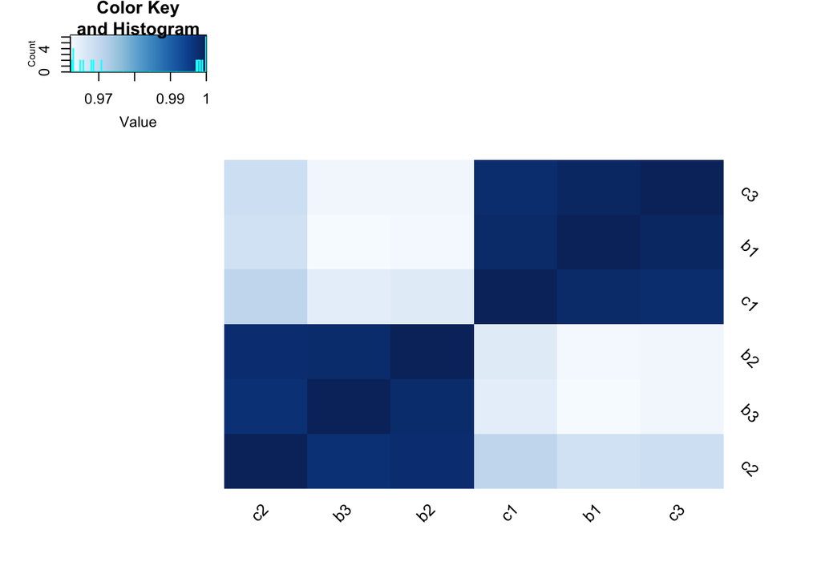

```
- Scatterplot the six data samples with respect to the first two principal components and label the samples.
```

```r
mapPearsonCorr<- heatmap.2(pcorrelation,dendrogram = "none", scale="none", trace="none",col=PuRd(256), cexCol=1.0,cexRow=1.0, srtRow =-45, srtCol = 45)
```

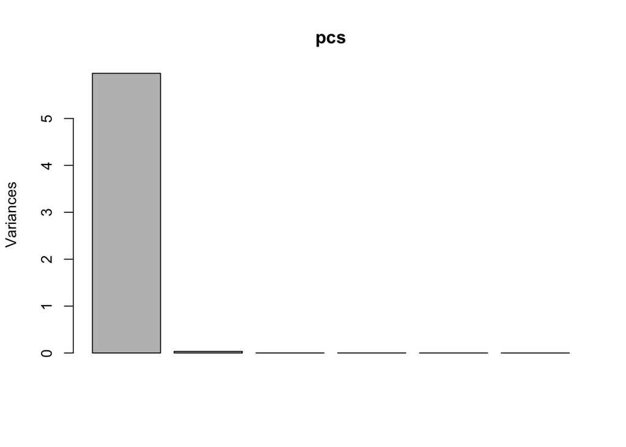

```r
pcs <- prcomp(Q6data, center = F, scale = T)

# plot
plot(pcs)
```

```r
toPlotPCS<-pcs$rotation
dimnames(toPlotPCS)
```

```
## [[1]]
## [1] "b1" "b2" "b3" "c1" "c2" "c3"
##
## [[2]]
## [1] "PC1" "PC2" "PC3" "PC4" "PC5" "PC6"
```

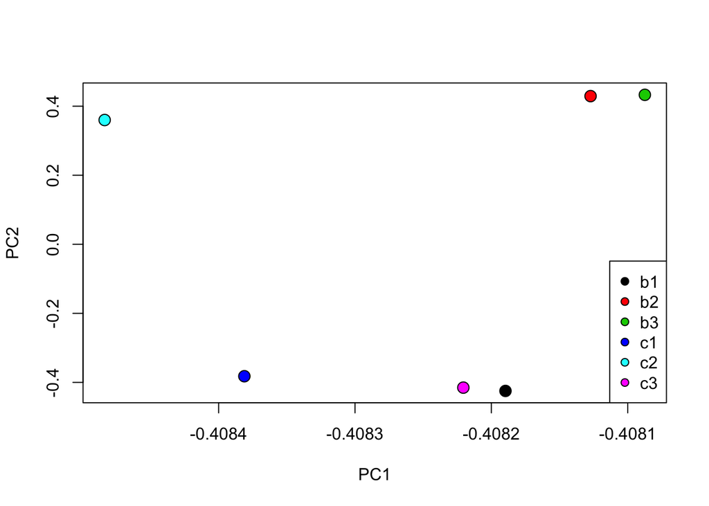

```r
plot(toPlotPCS[,c("PC1","PC2")], bg = as.factor(dimnames(toPlotPCS)[[1]]), pch = 21, cex = 1.5)
legend("bottomright", dimnames(toPlotPCS)[[1]], pch = 21, pt.bg = c(1,2,3,4,5,6))
```

#### 6.2 Microarray DEA (2 points)

- Fix the label swap identified in the previous question.

Here I swap the labels and save them under another variable name “fixedQ6data”

```r
fixedQ6data <- Q6data
colnames(fixedQ6data)[1] <- "c2"
colnames(fixedQ6data)[5] <- "b1"
colnames(fixedQ6data)
```

```
## [1] "c2" "b2" "b3" "c1" "b1" "c3"
```

- Now use this data to do a differential expression analysis with `limma`. Package these results in a data frame with six columns:
  - probe.id - The array probe id.
  - gene.id - The id of the gene which the probe overlaps (see below).
  - p.value - The raw p-value for the probe.
  - q.value - The BH corrected p-value, aka the q-value.
  - log.fc - The log fold change which is the column called “logFC” in the limma results table.
  - test.stat - The test statistics which for limma is the moderated t statistic. This is the column called “t” in the limma results table.

> You can retrieve the gene IDs using the `yeast2.db` package from Bioconductor:

```r
#source("http://bioconductor.org/biocLite.R")    # Installing biocLite package
#biocLite()                                         # Load the package
#biocLite("yeast2.db")                          # Download the package using biocLite
library("yeast2.db")                            # Load the yeast2.db package
#mget("1772391_at", yeast2ORF)                      # See what gene is that probe for
#gene.ids <- unlist(mget(probe.id, yeast2ORF))  # See all the genes for the list of probes
```

This is where I construct my data.frame as specified in the question.

```r
sample.id <- as.vector(colnames(fixedQ6data))
condition <- c( "chemostat", "batch-medium", "batch-medium", "chemostat","batch-medium", "chemostat")
metadata <- data.frame(sample.id, condition)
library("limma")
design <- model.matrix(~ 0 + condition, metadata)
colnames(design) <- c("batch.medium", "chemostat")
Q6Fit <- lmFit(fixedQ6data, design)
Q6ebayes <- eBayes(Q6Fit)

# contrasts
Q6contrast <- makeContrasts(batch.medium-chemostat, levels=design)
Q6Fit2 <- contrasts.fit(Q6Fit, Q6contrast)
Q6ebayes2 <- eBayes(Q6Fit2)
Q6hits <- topTable(Q6ebayes2, coef=1, adjust = "fdr", number = 'inf')
str(Q6hits)
```

```
## 'data.frame':    10928 obs. of  6 variables:
##  $ logFC    : num  -10.11 -8.47 -8.99 -7.3 -8.58 ...
##  $ AveExpr  : num  7.04 6.85 8.38 5.43 6.89 ...
##  $ t        : num  -108.9 -89.9 -80.7 -72.7 -71.3 ...
##  $ P.Value  : num  9.48e-14 4.28e-13 9.93e-13 2.25e-12 2.62e-12 ...
##  $ adj.P.Val: num  1.04e-09 2.34e-09 3.62e-09 5.72e-09 5.72e-09 ...
##  $ B        : num  21 20.1 19.5 18.9 18.7 ...
```

```r
# So, we would like our data frame to have the following sixcolumns:
    # - probe.id
    # - gene.id
    # - p.value
    # - q.value
    # - log.fc
    # - test.stat
probe.id <- unlist(rownames(Q6hits))
gene.id <- unlist(mget(probe.id, yeast2ORF))  # See all the genes for the list of probes

myFrame <- data.frame(probe.id, gene.id, p.value = Q6hits$P.Value, q.value = Q6hits$adj.P.Val, log.fc = Q6hits$logFC, test.stat = Q6hits$t)

str(myFrame)
```

```
## 'data.frame':    10928 obs. of  6 variables:
##  $ probe.id : Factor w/ 10928 levels "1769308_at","1769309_at",..: 3020 4709 4658 6704 4660 6852 1250 4608 6834 7323 ...
##  $ gene.id  : Factor w/ 5657 levels "YAL001C","YAL002W",..: 2593 5213 4299 4200 3019 1107 563 4166 5175 1943 ...
##  $ p.value  : num  9.48e-14 4.28e-13 9.93e-13 2.25e-12 2.62e-12 ...
##  $ q.value  : num  1.04e-09 2.34e-09 3.62e-09 5.72e-09 5.72e-09 ...
##  $ log.fc   : num  -10.11 -8.47 -8.99 -7.3 -8.58 ...
##  $ test.stat: num  -108.9 -89.9 -80.7 -72.7 -71.3 ...
```

#### 6.3 Microarray DEA continue (1 point)

- Remove any rows with probes which don’t map to genes. You’ll be able to find these because they will have `NA` as their gene id.

```r
# How many NAs do we have?
sum((is.na(myFrame$gene.id)))
```

```
## [1] 5223
```

```r
# That must mean we have ...
sum((!is.na(myFrame$gene.id)))
```

```
## [1] 5705
```

```r
# ... which aren't NAs

# so let's filter these NAs out of our frame
myFilteredFrame<-myFrame[which(!is.na(myFrame$gene.id)),]

# Let's take a peek and see if my method of filtering NAs will do what we expect it to
tail(myFrame)
```

```
##              probe.id gene.id   p.value   q.value        log.fc
## 1777665_at 1777665_at YOR368W 0.9975345 0.9979912 -2.170748e-04
## 1779984_at 1779984_at    <NA> 0.9978900 0.9982554  4.024972e-04
## 1769963_at 1769963_at    <NA> 0.9981306 0.9983919 -3.348665e-04
## 1770373_at 1770373_at    <NA> 0.9982091 0.9983919 -4.174484e-04
## 1776546_at 1776546_at YDL037C 0.9999942 1.0000000 -7.109085e-07
## 1769489_at 1769489_at    <NA> 1.0000000 1.0000000 -3.330669e-15
##                test.stat
## 1777665_at -3.189874e-03
## 1779984_at  2.729949e-03
## 1769963_at -2.418666e-03
## 1770373_at -2.317064e-03
## 1776546_at -7.468710e-06
## 1769489_at -4.013252e-14
```

```r
# some entries at the tail have NAs

tail(myFilteredFrame)
```

```
##              probe.id gene.id   p.value   q.value        log.fc
## 1769541_at 1769541_at YPR042C 0.9882557 0.9915220  1.261276e-03
## 1776332_at 1776332_at YLR403W 0.9913084 0.9937001 -8.169220e-04
## 1777350_at 1777350_at YAL060W 0.9944034 0.9955878 -7.172949e-04
## 1771787_at 1771787_at YBR165W 0.9962051 0.9970263  3.353180e-04
## 1777665_at 1777665_at YOR368W 0.9975345 0.9979912 -2.170748e-04
## 1776546_at 1776546_at YDL037C 0.9999942 1.0000000 -7.109085e-07
##                test.stat
## 1769541_at  1.519573e-02
## 1776332_at -1.124562e-02
## 1777350_at -7.241079e-03
## 1771787_at  4.909898e-03
## 1777665_at -3.189874e-03
## 1776546_at -7.468710e-06
```

- How many probes did we start with and how many remain after removing probes without gene ids?

With NA’s I have 10928 probes, and without I have 5705 probes.

- Illustrate the differential expression between the batch and the chemostat samples for the top hit (i.e., probe with the lowest p- or q-value).

```r
# With NA's we have 10928 probes ...
dim(myFrame)[1]
```

```
## [1] 10928
```

```r
# Without NA's we have 5705 probes
dim(myFilteredFrame)[1]
```

```
## [1] 5705
```

- How many probes are identified as differentially expressed at a false discovery rate (FDR) of 1e-5 (note: this is a FDR cutoff used in the original paper)?

I found 725 differentially expressed at a FDR 1e-5

```r
table(myFilteredFrame$q.value<1e-5)
```

```
##
## FALSE  TRUE
##  4980   725
```

- Save this data.frame for later with `write.table()`

> When using write.table to save the data, you need to pass the arguments `row.names = TRUE, col.names = NA` to make sure the headers are written correctly.

```r
write.table(myFilteredFrame, file = "data/Q6frame.txt", append = FALSE, quote = TRUE, sep = " ",
            eol = "\n", na = "NA", dec = ".", row.names = TRUE,
            col.names = NA, qmethod = c("escape", "double"),
            fileEncoding = "")
```

### Question 7: RNA-seq analysis

We have aligned the RNA-Seq library using the [Stampy](http://www.well.ox.ac.uk/project-stampy) aligner and generated count data. This particular RNA-Seq dataset was sequenced to quite a high depth. The data file is available as stampy.deep.counts.tsv. In this question you will use this data to do a differential expression analysis.

#### 7.1 Load RNA Count Data and Sanity Check (1 point)

Load the count data using `read.table`; you will need to pass the arguments `header=TRUE` and `row.names=1`.

```r
count.data <- read.table("data/stampy.deep.counts.tsv", header=T, row.names = 1)
```

- What are dimensions of the dataset? In addition to reporting number of rows and columns, make it clear what rows and columns represent. What is the difference between the rows of this dataset versus rows of the array data in question 1a?

Columns represent sample, rows represent gene. The dimensions are 6542 rows and 6 columns

```r
dim(count.data)
```

```
## [1] 6542    6
```

- Do a sanity check to make sure there is no sample swap by plotting a heatmap of the sample correlations.

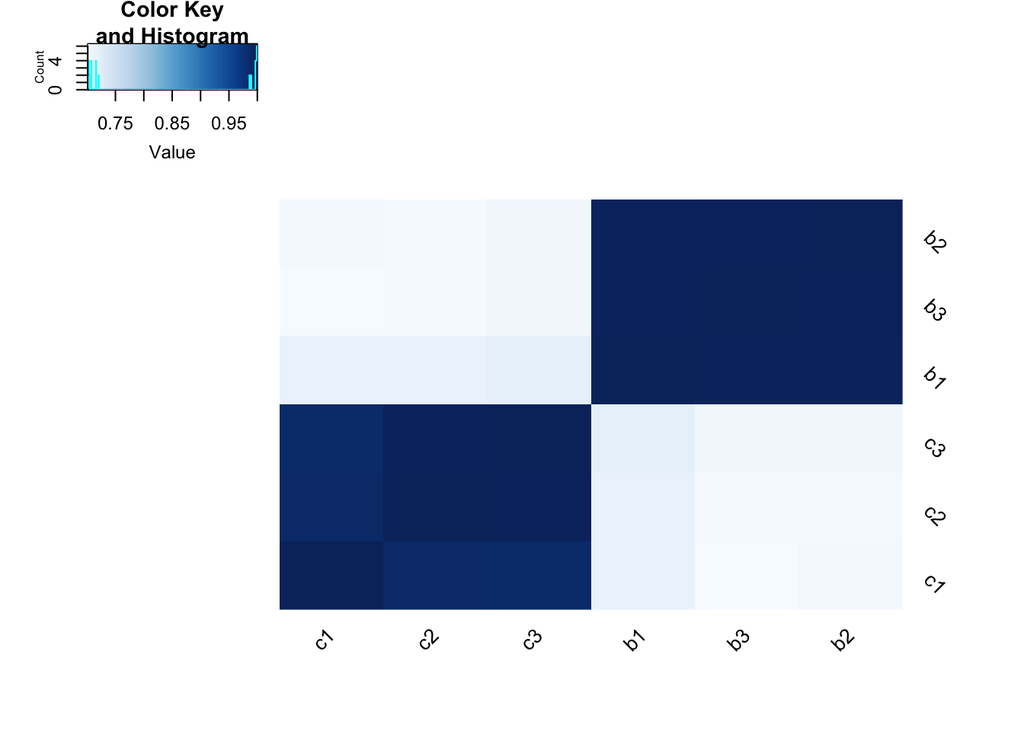

```r
sample.corr <- cor(count.data, method = "pearson")

mapCorr<- heatmap.2(sample.corr,dendrogram = "none", scale="none", trace="none",col=PuRd(256), cexCol=1.0,cexRow=1.0, srtRow =-45, srtCol = 45)
```

#### 7.2 DEA of deep sequencing data (1 point)

Now you will use `edgeR` to identify differentially expressed genes between the batch medium vs. chemostat conditions.

```r
library("edgeR")

with(metadata,table(condition))
```

```
## condition
## batch-medium    chemostat
##            3            3
```

```r
group <- factor(c(rep("batch-medium",3),rep("chemostat",3)))
group
```

```
## [1] batch-medium batch-medium batch-medium chemostat    chemostat
## [6] chemostat
## Levels: batch-medium chemostat
```

```r
dge.glm <- DGEList(counts=count.data, group=group)
str(dge.glm)
```

```
## Formal class 'DGEList' [package "edgeR"] with 1 slot
##   ..@ .Data:List of 2
##   .. ..$ : int [1:6542, 1:6] 11 40 31 63 112 17 0 4 5 0 ...
##   .. .. ..- attr(*, "dimnames")=List of 2
##   .. .. .. ..$ : chr [1:6542] "15S_rRNA" "21S_rRNA" "HRA1" "ICR1" ...
##   .. .. .. ..$ : chr [1:6] "b1" "b2" "b3" "c1" ...
##   .. ..$ :'data.frame':  6 obs. of  3 variables:
##   .. .. ..$ group       : Factor w/ 2 levels "batch-medium",..: 1 1 1 2 2 2
##   .. .. ..$ lib.size    : num [1:6] 3420851 4487585 3415378 2529571 2990956 ...
##   .. .. ..$ norm.factors: num [1:6] 1 1 1 1 1 1
```

```r
nrow(dge.glm[[1]])
```

```
## [1] 6542
```

```r
model <- model.matrix(~group)
```

- Recall that `edgeR` needs to estimate the dispersion parameter in the negative binomial model using an empirical Bayes method. Estimate the dispersion parameters using `estimateGLMCommonDisp`, `estimateGLMTrendedDisp` and `estimateGLMTagwiseDisp`.

```r
dge.glm.com.disp <- estimateGLMCommonDisp(dge.glm, model, verbose=TRUE)
```

```
## Disp = 0.00551 , BCV = 0.0742
```

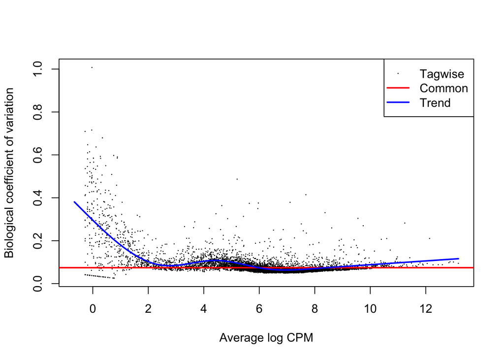

```r
dge.glm.trend.disp <- estimateGLMTrendedDisp(dge.glm.com.disp, model)
dge.glm.tag.disp <- estimateGLMTagwiseDisp(dge.glm.trend.disp, model)
plotBCV(dge.glm.tag.disp)
```

- Use the glm functionality of `edgeR`, i.e. use the `glmFit` function, to identify differentially expressed genes between conditions.

```r
fit <- glmFit(dge.glm.tag.disp,model)
colnames(coef(fit))
```

```
## [1] "(Intercept)"    "groupchemostat"
```

```r
lrt <- glmLRT(fit,coef=2)
```

- How many genes are differentially expressed between conditions at a false discovery rate (FDR) of 1e-5?

2669 are differentially expressed between conditions at FDR < 1e-5

```r
tt.glm <- topTags(lrt, n=Inf)
class(tt.glm)
```

```
## [1] "TopTags"
## attr(,"package")
## [1] "edgeR"
```

```r
table(tt.glm$table$FDR < 1e-5)
```

```
##
## FALSE  TRUE
##  3873  2669
```

```r
#nrow(tt.glm$table[tt.glm$table$FDR < 1e-5,])

interestingGenes <- tt.glm$table[tt.glm$table$FDR < 1e-5,]

# let's just check that we have all our interesting sample counts
dim(interestingGenes)
```

```
## [1] 2669    5
```

- Package these results in a data.frame called ‘edger.deep.results’ with five columns:
  - gene.id - The id of the gene which reads were aligned to.
  - p.value - The raw p-value for the gene.
  - q.value - The BH corrected p-value, aka the q-value.
  - log.fc - The log fold change which is the column called “logFC” in the `edgeR` results table.
  - test.stat - The test statistic, which for `edgeR` is a likelihood ratio. This is the column called “LR” in the `edgeR` results table.
- Save this data.frame for later with `write.table()`

```r
gene.id <- rownames(interestingGenes)
p.value <- interestingGenes$PValue
q.value <- interestingGenes$FDR
log.fc <- interestingGenes$logFC
test.stat <- interestingGenes$LR
edger.deep.results <- data.frame(gene.id, p.value, q.value, log.fc,test.stat)
dim(edger.deep.results)
```

```
## [1] 2669    5
```

```r
write.table(edger.deep.results, file = "data/edger.deep.results.txt", append = FALSE, quote = TRUE, sep = " ",
            eol = "\n", na = "NA", dec = ".", row.names = TRUE,
            col.names = NA, qmethod = c("escape", "double"),
            fileEncoding = "")
```

#### 7.3 DEA of low sequencing data (1 point)

Sequencing depth is a major factor in RNA-Seq analysis; as rule of thumb, the deeper you sequence the more power you have. To investigate this claim, we have created a low depth dataset by randomly selecting 1% of the reads and discarding the remaining 99%. This low depth count data was also aligned with Stampy.

- Load the low depth count data using `read.table`; you will need to pass the arguments `header=TRUE` and `row.names=1`. The data file is available as stampy.low.counts.tsv

```r
low.count.data <- read.table("data/stampy.low.counts.tsv", header=T, row.names = 1)
str(low.count.data)
```

```
## 'data.frame':    7126 obs. of  6 variables:
##  $ b1: int  0 4 3 21 1 33 6 3 14 1 ...
##  $ b2: int  0 10 13 36 1 31 2 11 28 0 ...
##  $ b3: int  0 5 7 16 1 24 4 5 24 0 ...
##  $ c1: int  0 9 6 11 0 26 6 5 8 0 ...
##  $ c2: int  0 5 5 3 2 23 8 6 9 0 ...
##  $ c3: int  0 16 10 6 0 37 11 7 17 0 ...
```

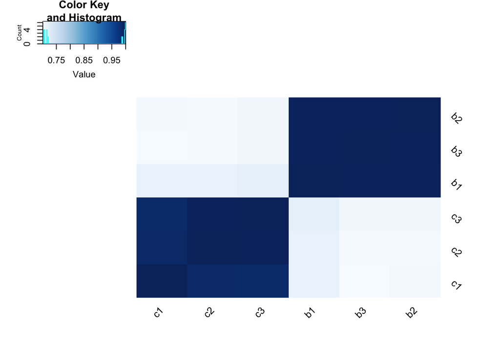

```r
# Even though this wasn't specified, I'd like to check that our samples are labelled correctly
low.sample.corr <- cor(low.count.data, method = "pearson")

heatmap.2(sample.corr,dendrogram = "none", scale="none", trace="none",col=PuRd(256), cexCol=1.0,cexRow=1.0, srtRow =-45, srtCol = 45)
```

- Repeat the same steps as in 7.2 except package your results in a data.frame called “edger.low.results”. Answer the same questions.

```r
with(metadata,table(condition))
```

```
## condition
## batch-medium    chemostat
##            3            3
```

```r
group <- factor(c(rep("batch-medium",3),rep("chemostat",3)))
group
```

```
## [1] batch-medium batch-medium batch-medium chemostat    chemostat
## [6] chemostat
## Levels: batch-medium chemostat
```

```r
low.dge.glm <- DGEList(counts=low.count.data, group=group)
str(low.dge.glm)
```

```
## Formal class 'DGEList' [package "edgeR"] with 1 slot
##   ..@ .Data:List of 2
##   .. ..$ : int [1:7126, 1:6] 0 4 3 21 1 33 6 3 14 1 ...
##   .. .. ..- attr(*, "dimnames")=List of 2
##   .. .. .. ..$ : chr [1:7126] "YHR055C" "YPR161C" "YOL138C" "YDR395W" ...
##   .. .. .. ..$ : chr [1:6] "b1" "b2" "b3" "c1" ...
##   .. ..$ :'data.frame':  6 obs. of  3 variables:
##   .. .. ..$ group       : Factor w/ 2 levels "batch-medium",..: 1 1 1 2 2 2
##   .. .. ..$ lib.size    : num [1:6] 76990 100953 75435 55758 66758 ...
##   .. .. ..$ norm.factors: num [1:6] 1 1 1 1 1 1
```

```r
nrow(low.dge.glm[[1]])
```

```
## [1] 7126
```

```r
low.model <- model.matrix(~group)

##################################
low.dge.glm.com.disp <- estimateGLMCommonDisp(low.dge.glm, low.model, verbose=TRUE)
```

```
## Disp = 0.0042 , BCV = 0.0648
```

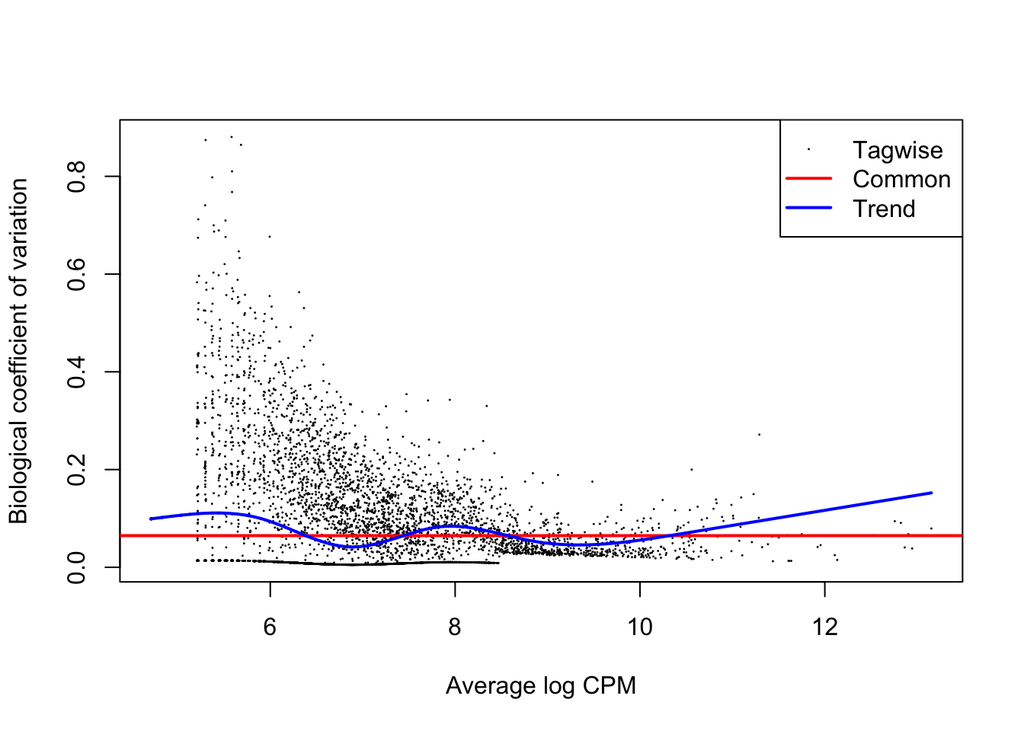

```r
low.dge.glm.trend.disp <- estimateGLMTrendedDisp(low.dge.glm.com.disp, low.model)
low.dge.glm.tag.disp <- estimateGLMTagwiseDisp(low.dge.glm.trend.disp, low.model)
plotBCV(low.dge.glm.tag.disp)
```

```r
###################################
low.fit <- glmFit(low.dge.glm.tag.disp,low.model)
colnames(coef(low.fit))
```

```
## [1] "(Intercept)"    "groupchemostat"
```

```r
low.lrt <- glmLRT(low.fit,coef=2)

low.tt.glm <- topTags(low.lrt, n=Inf)
class(low.tt.glm)
```

```
## [1] "TopTags"
## attr(,"package")
## [1] "edgeR"
```

```r
table(low.tt.glm$table$FDR < 1e-5)
```

```
##
## FALSE  TRUE
##  6640   486
```

```r
#nrow(tt.glm$table[tt.glm$table$FDR < 1e-5,])

low.interestingGenes <- low.tt.glm$table[low.tt.glm$table$FDR < 1e-5,]

# let's just check that we have all our interesting sample counts
dim(low.interestingGenes)
```

```
## [1] 486   5
```

```r
low.gene.id <- rownames(low.interestingGenes)
low.p.value <- low.interestingGenes$PValue
low.q.value <- low.interestingGenes$FDR
low.log.fc <- low.interestingGenes$logFC
low.test.stat <- low.interestingGenes$LR
edger.low.results <- data.frame(low.gene.id, low.p.value, low.q.value, low.log.fc, low.test.stat)
dim(edger.low.results)
```

```
## [1] 486   5
```

```r
write.table(edger.low.results, file = "data/edger.low.results.txt", append = FALSE, quote = TRUE, sep = " ",
            eol = "\n", na = "NA", dec = ".", row.names = TRUE,
            col.names = NA, qmethod = c("escape", "double"),
            fileEncoding = "")
```

#### 7.4 Deep vs low sequencing (1 point)

Create a Venn diagram showing all genes identified as differentially expressed (at FDR of 1e-5) in the two previous RNA-Seq analyses and answer the following questions based on the diagram:

- How many genes were identified by edgeR in both low and deep count data?
- How many genes were identified in all the analyses?
- Comment on the effect of sequencing depth on the DEA results.

```r
#install.packages('VennDiagram')
library(VennDiagram)
```

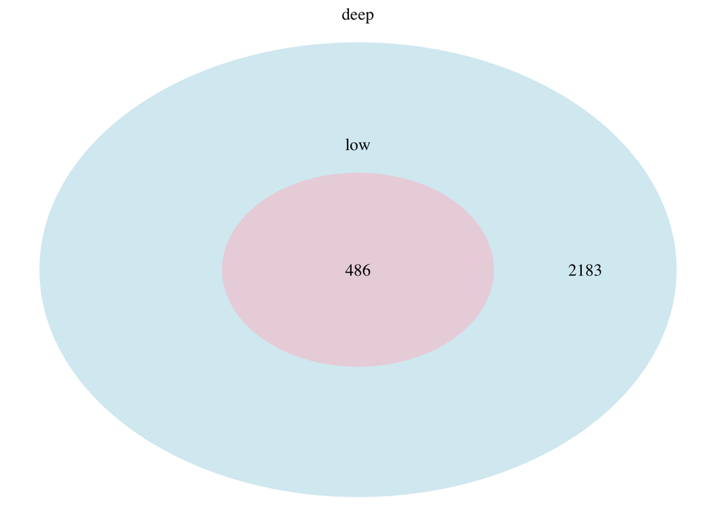

```
## (polygon[GRID.polygon.610], polygon[GRID.polygon.611], polygon[GRID.polygon.612], polygon[GRID.polygon.613], text[GRID.text.614], text[GRID.text.615], text[GRID.text.616], text[GRID.text.617])
```

```r
diff <- setdiff(rownames(edger.deep.results),rownames(edger.low.results))
inter <- intersect(rownames(edger.deep.results),rownames(edger.low.results))
unio <- union(rownames(edger.deep.results),rownames(edger.low.results))

grid.newpage()
draw.pairwise.venn(length(rownames(edger.deep.results)), length(rownames(edger.low.results)), length(inter), category = c("deep", "low"), lty = rep("blank",
    2), fill = c("light blue", "pink"), alpha = rep(0.5, 2), cat.pos = c(0,
    0), cat.dist = rep(0.025, 2))
```

### Question 8: Compare DEA results from RNA-Seq and arrays

In question 6, you performed a DEA of array data using limma. In question 7, you used edgeR to perform DEA of RNA-Seq data. In this question, you will compare the results of RNA-Seq DEA with those of the array DEA.

> Remember that you’ve packaged your results and saved them using write.table(). If the data.frames containing the results of these analyses are no longer in your workspace, you can load them using read.table().